# User Guide

### wl_guide

The examples for `stat_wl_strip` can be simplified by use of `wl_guide()` which adds both the statistics and the scale, and provides default *mappings* for both `ymin` (`-Inf`) and `ymax` (`Inf`). Another important difference is that the `"rect"` *geom* used cannot be set to a different one by the user.

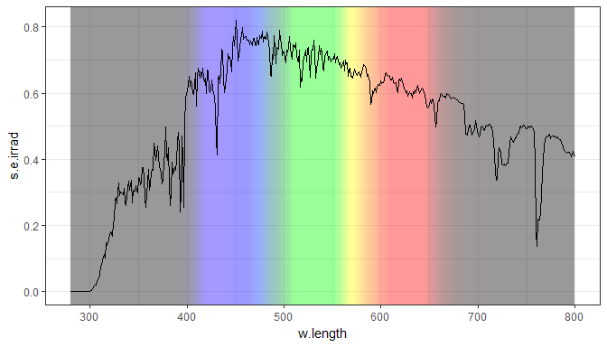

```r
ggplot(sun.spct) +
  wl_guide(alpha = 0.4) +
  geom_line()
```

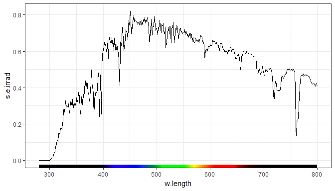

```r
ggplot(sun.spct) +
  wl_guide(ymax = -0.025) +
  geom_line()
```

This example produces a plot with a very different look than earlier ones, but can also be achieved with a very succinct statement.

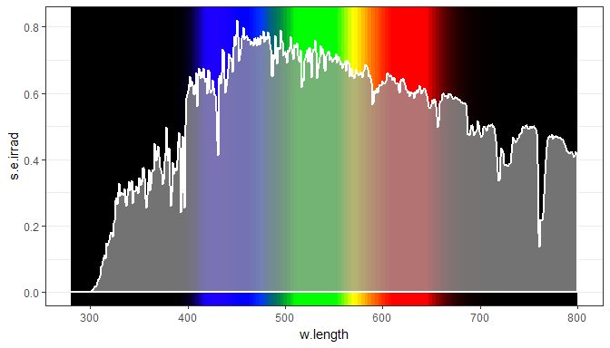

```r
ggplot(sun.spct) +
  wl_guide() +
  geom_spct(alpha = 0.75, colour = "white", size = 1)
```

In the next example we demonstrate a trick achieved by overploting two line of different width (`size`) to make the spectrum visible on a background of variable luminosity.

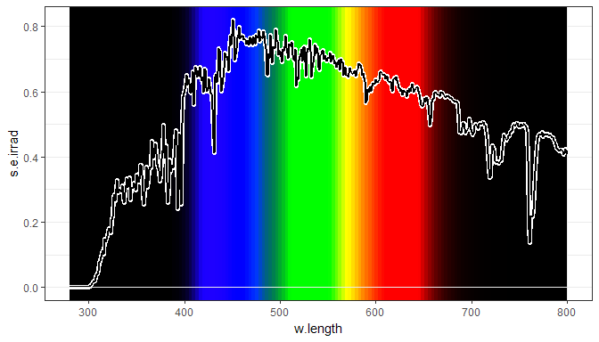

```r
ggplot(sun.spct) +
  wl_guide() +
  geom_line(size = 2, colour = "white") +
  geom_line(size = 1, colour = "black") +
  geom_hline(yintercept = 0, colour = "grey92") +
  theme_bw()
```

## Color charts

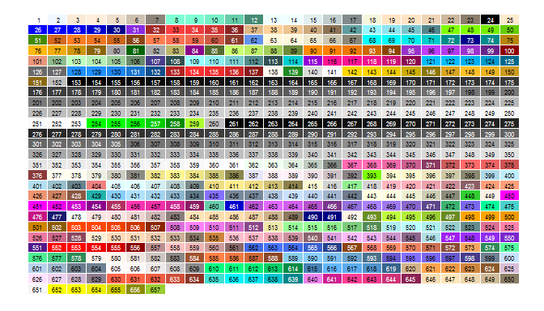

```r
color_chart(colors())
```

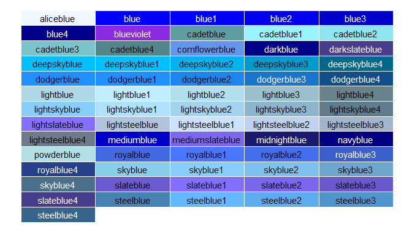

```r
color_chart(grep("blue", colors(), value = TRUE), ncol = 5, text.size = 4)
```

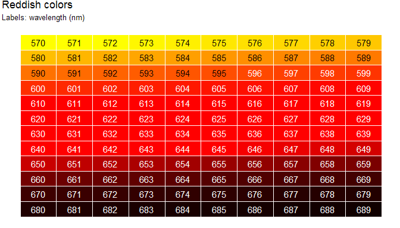

```r
 color_chart(w_length2rgb(570:689, color.name = as.character(570:689)),
            use.names = TRUE, text.size = 4) +
  ggtitle("Reddish colors", subtitle = "Labels: wavelength (nm)")
```